# Дисперсионный анализ. Пример

Загрузим данные (требуется установить Рабочую папку с помощью setwd) или указать полный путь

```r
data = read.csv("../data/diet.csv",row.names=1)
summary(data)
```

```
##      gender            Age            Height        pre.weight
##  Min.   :0.0000   Min.   :16.00   Min.   :141.0   Min.   : 58.00
##  1st Qu.:0.0000   1st Qu.:32.25   1st Qu.:164.2   1st Qu.: 66.00
##  Median :0.0000   Median :39.00   Median :169.5   Median : 72.00
##  Mean   :0.4342   Mean   :39.15   Mean   :170.8   Mean   : 72.53
##  3rd Qu.:1.0000   3rd Qu.:46.75   3rd Qu.:174.8   3rd Qu.: 78.00
##  Max.   :1.0000   Max.   :60.00   Max.   :201.0   Max.   :103.00
##  NA's   :2
##       Diet        weight6weeks
##  Min.   :1.000   Min.   : 53.00
##  1st Qu.:1.000   1st Qu.: 61.85
##  Median :2.000   Median : 68.95
##  Mean   :2.038   Mean   : 68.68
##  3rd Qu.:3.000   3rd Qu.: 73.83
##  Max.   :3.000   Max.   :103.00
##
```

Ознакомимся со структурой и переименуем колонки, как нам удобно

_https://www.sheffield.ac.uk/polopoly_fs/1.547015!/file/Diet_data_description.docx_

_https://www.sheffield.ac.uk/mash/data_

```r
colnames(data) <- c("gender", "age", "height", "initial.weight",
                    "diet.type", "final.weight")

data$diet.type <- factor(c("A", "B", "C")[data$diet.type])
```

Добавим новую колонку - Похудение

```r
data$weight.loss = data$initial.weight - data$final.weight
```

Проанализиуем есть ли различия по типам диет

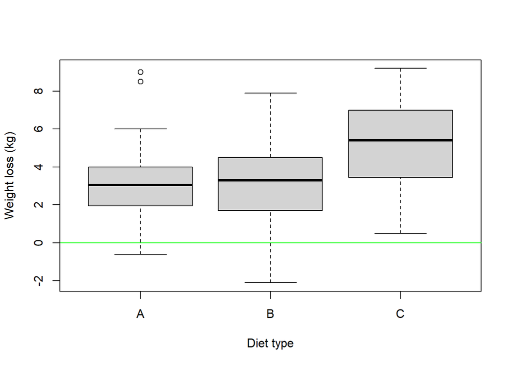

```r
boxplot(weight.loss~diet.type,data=data,col="light gray",
        ylab = "Weight loss (kg)", xlab = "Diet type")
abline(h=0,col="green")
```

Проверим сбалансированные ли данные

```r
table(data$diet.type)
```

```
##
##  A  B  C
## 24 27 27
```

График групповых средних

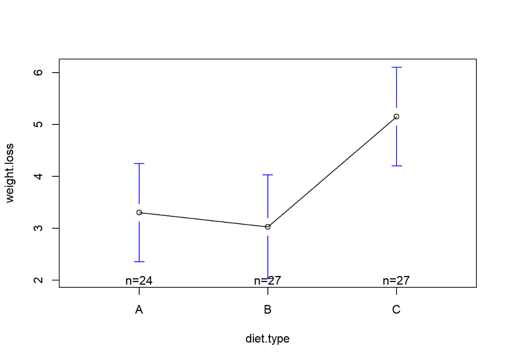

```r
library(gplots) #библиотека устанавлевается с помощью install.packages
plotmeans(weight.loss ~ diet.type, data=data)
```

```r
agr1<-aggregate(data$weight.loss, by = list(data$diet.type), FUN=sd)
agr1
```

```
##   Group.1        x
## 1       A 2.240148
## 2       B 2.523367
## 3       C 2.395568
```

Для подгонки *ANOVA* модели используем функцию `aov`, частный случай линейной модели `lm`

1. тест на межгрупповые различия:

```r
fit <- aov(weight.loss ~ diet.type, data=data)
summary(fit)
```

```
##             Df Sum Sq Mean Sq F value  Pr(>F)
## diet.type    2   71.1   35.55   6.197 0.00323 **
## Residuals   75  430.2    5.74
## ---
## Signif. codes:  0 '***' 0.001 '**' 0.01 '*' 0.05 '.' 0.1 ' ' 1
```

2. попарные различия между средними значениями для всех групп

```r
TukeyHSD(fit)
```

```
##   Tukey multiple comparisons of means
##     95% family-wise confidence level
##
## Fit: aov(formula = weight.loss ~ diet.type, data = data)
##
## $diet.type
##           diff        lwr      upr     p adj
## B-A -0.2740741 -1.8806155 1.332467 0.9124737
## C-A  1.8481481  0.2416067 3.454690 0.0201413
## C-B  2.1222222  0.5636481 3.680796 0.0047819
```

Tukey honest significant differences test

```r
library(multcomp)
```

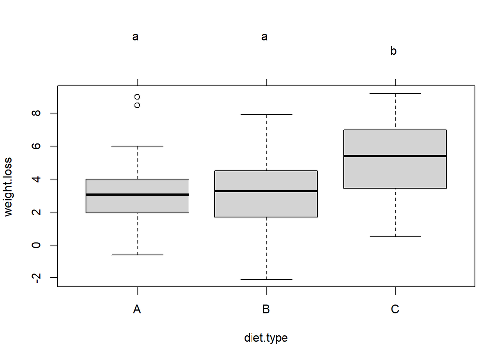

```r
par(mar=c(5,4,6,2))
tuk <- glht(fit, linfct=mcp(diet.type="Tukey"))
plot(cld(tuk, level=.05),col="lightgrey")
```

# Задание

### 1. Добавить проверку на выбросы и избавиться от них

Уберем данные о потере веса, содержащие слишком большое значение, и данные о людях, которые потолстели на данной диете

```r
data.without.outlier<-data[data$weight.loss<=8.2 & data$weight.loss>0,]
```

### 2. повторно проверсти все тесты и сравнить результаты с выбросами и без

2.1. График “коробочка с усами” стал более ровный

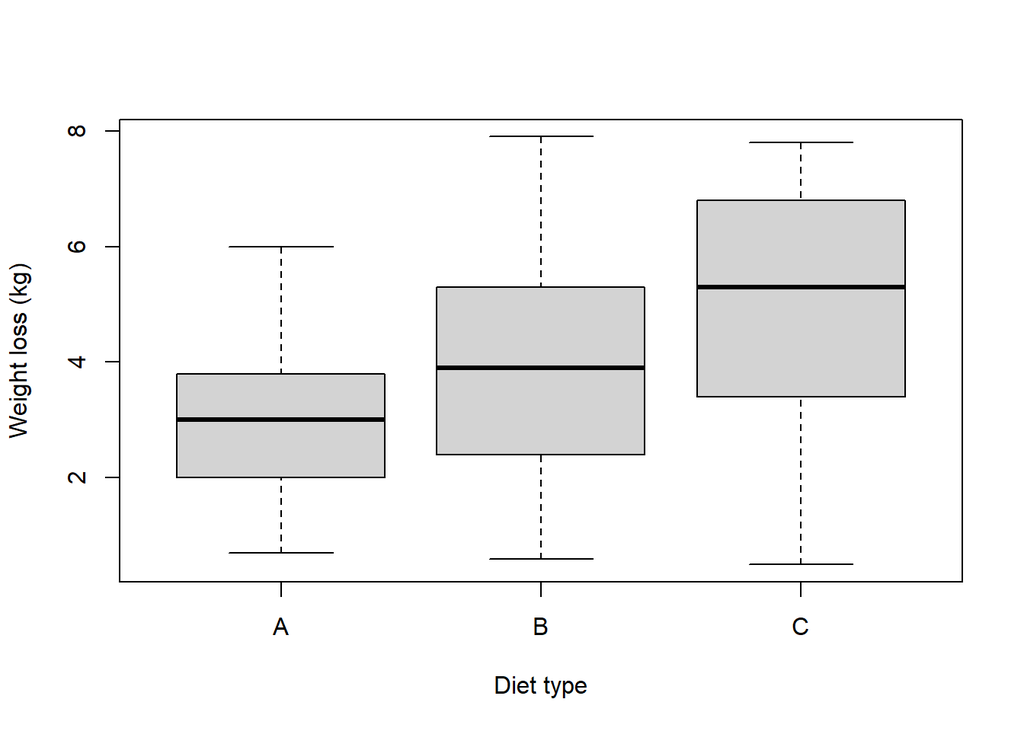

```r
boxplot(weight.loss~diet.type,data=data.without.outlier,col="light gray",
        ylab = "Weight loss (kg)", xlab = "Diet type")
```

2.2. Проверим график групповых средних

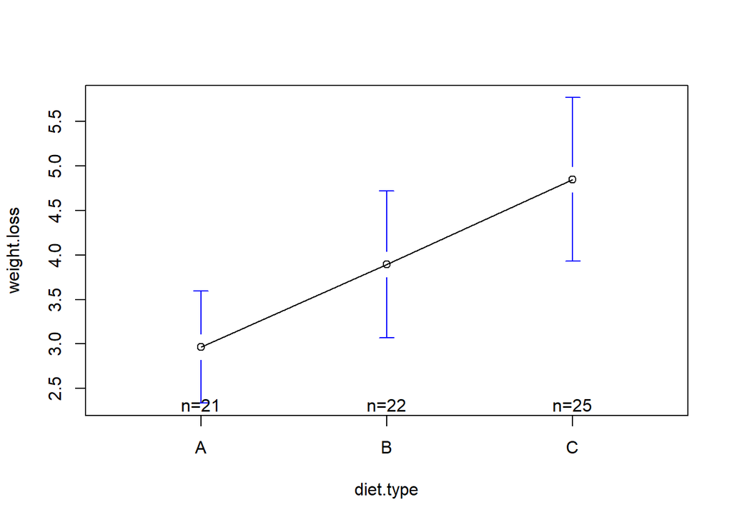

```r
plotmeans(weight.loss ~ diet.type, data=data.without.outlier)
```

2.3. Проверим изменение значения ф-ии `sd` на группы по диетам после избавления от выбросов

```r
agr2<-aggregate(data.without.outlier$weight.loss, by = list(data.without.outlier$diet.type), FUN=sd)
sum.aggregate<-data.frame("С выбросами"=agr1,"Без выбросов"=agr2)
sum.aggregate
```

```
##   С.выбросами.Group.1 С.выбросами.x Без.выбросов.Group.1 Без.выбросов.x
## 1                   A      2.240148                    A       1.384678
## 2                   B      2.523367                    B       1.855616
## 3                   C      2.395568                    C       2.223196
```

2.4. тест на межгрупповые различия:

```r
fit2 <- aov(weight.loss ~ diet.type, data=data.without.outlier)
summary(fit2)
```

```
##             Df Sum Sq Mean Sq F value  Pr(>F)
## diet.type    2  40.53  20.263   5.745 0.00504 **
## Residuals   65 229.28   3.527
## ---
## Signif. codes:  0 '***' 0.001 '**' 0.01 '*' 0.05 '.' 0.1 ' ' 1
```

2.5. попарные различия между средними значениями для всех групп

```r
TukeyHSD(fit2)
```

```
##   Tukey multiple comparisons of means
##     95% family-wise confidence level
##
## Fit: aov(formula = weight.loss ~ diet.type, data = data.without.outlier)
##
## $diet.type
##          diff        lwr      upr     p adj
## B-A 0.9287879 -0.4455295 2.303105 0.2441535
## C-A 1.8813333  0.5478946 3.214772 0.0034358
## C-B 0.9525455 -0.3643199 2.269411 0.2000645
```

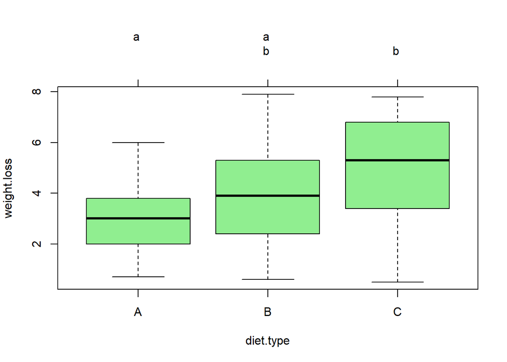

```r
par(mar=c(5,4,6,2))
tuk <- glht(fit2, linfct=mcp(diet.type="Tukey"))
plot(cld(tuk, level=.05),col="lightgreen")
```

Т.е. если сравнивать данные диеты, то на первом месте будет диета “С”, на втором “В”, на третьем “А”

### 3. Открыть документ https://www.sheffield.ac.uk/polopoly_fs/1.547015!/file/Diet_data_description.docx и попытаться выполнить задания из него

### 1.Есть ли разница потери веса от пола?

1. Подготовим данные для анализа, избавимся от значений NA в колонке gender

```r
data.without.na<-data.without.outlier[!(is.na(data.without.outlier$gender)),]
data.without.na$gender<-factor(c("Female","Male")[as.factor(data.without.na$gender)])
```

2. Построим диаграмму размаха пола относительно потери веса

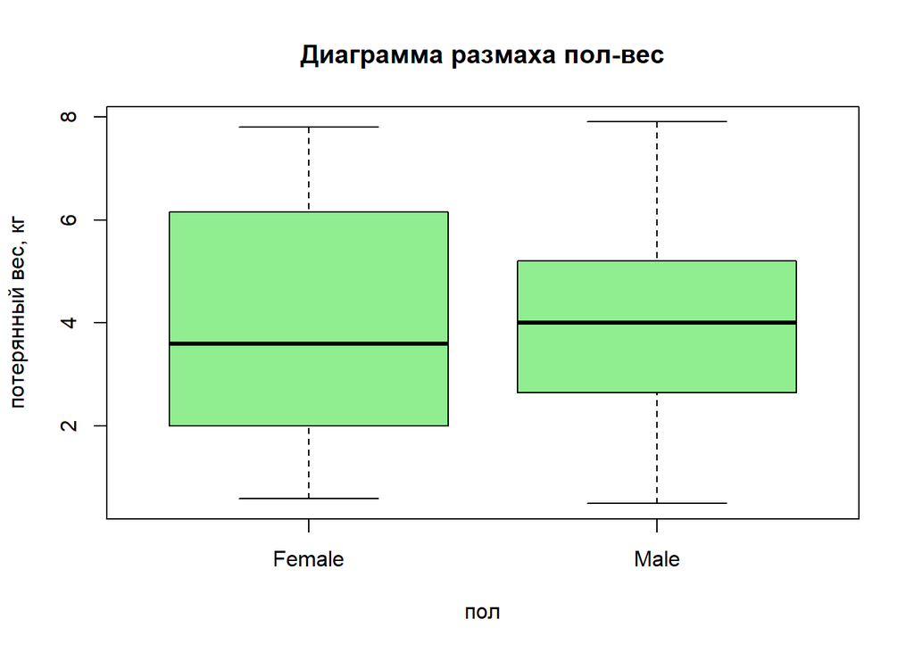

```r
boxplot(weight.loss ~ gender, data=data.without.na, xlab="пол", ylab="потерянный вес, кг",main="Диаграмма размаха пол-вес", col="lightgreen")
```

3. Проверим сбалансированность данных

```r
table(data.without.na$gender)
```

```
##
## Female   Male
##     40     28
```

После удаления выбросов и знчений NA, данные стали менее сбалансированы

4. Построим график групповых средних в зависимости от пола:

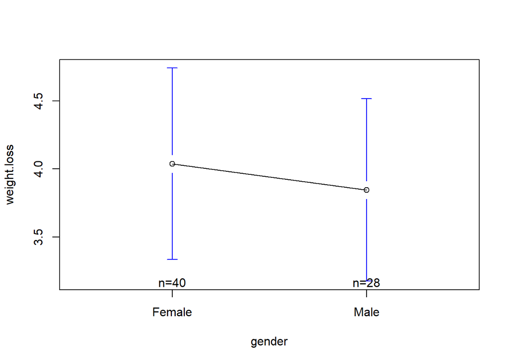

```r
plotmeans(weight.loss ~ gender, data=data.without.na)
```

```r
aggregate(data.without.na$weight.loss, by = list(data.without.na$gender), FUN=sd)
```

```
##   Group.1        x
## 1  Female 2.198914
## 2    Male 1.728087
```

Из графика видно, что средний сброшенный вес у женщин немного выше, чем у мужчин, но и среднеквадратичное отклонение у женщин больше

5. Подгонка ANOVA модели:

```r
fit.gender.without.outlier <- aov(weight.loss ~ gender, data=data.without.na)
summary(fit.gender.without.outlier)
```

```
##             Df Sum Sq Mean Sq F value Pr(>F)
## gender       1    0.6   0.601   0.147  0.702
## Residuals   66  269.2   4.079
```

6. Попарные различия между средними значениями для мужчин и женщин:

```r
TukeyHSD(fit.gender.without.outlier)
```

```
##   Tukey multiple comparisons of means
##     95% family-wise confidence level
##
## Fit: aov(formula = weight.loss ~ gender, data = data.without.na)
##
## $gender
##                   diff       lwr       upr     p adj
## Male-Female -0.1910714 -1.184638 0.8024954 0.7022449
```

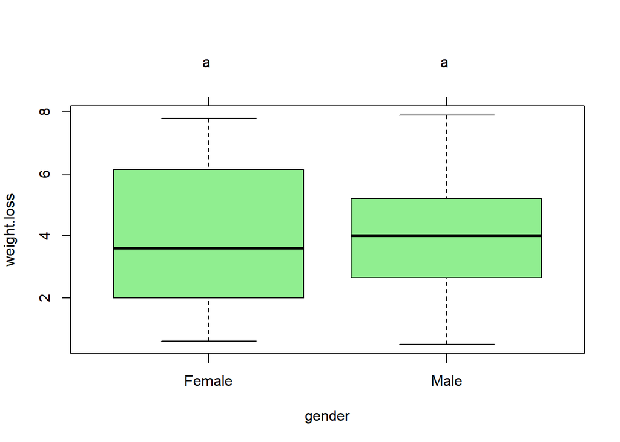

```r
par(mar=c(5,4,6,2))
tuk <- glht(fit.gender.without.outlier, linfct=mcp(gender="Tukey"))
plot(cld(tuk, level=.05),col="lightgreen")
```

Исходя из полученных данных, видно, что диеты влияют лучше на женщин (разница средних значений -0.19), чем на мужчин, но эта разница не значительна.

### Двухфакторный дисперсионный анализ зависимости величины потери веса от пола и типа диеты

1. Построим диаграмму размаха значений потери веса по типу диеты и полу:

Сброс веса -> Тип диеты ~ пол

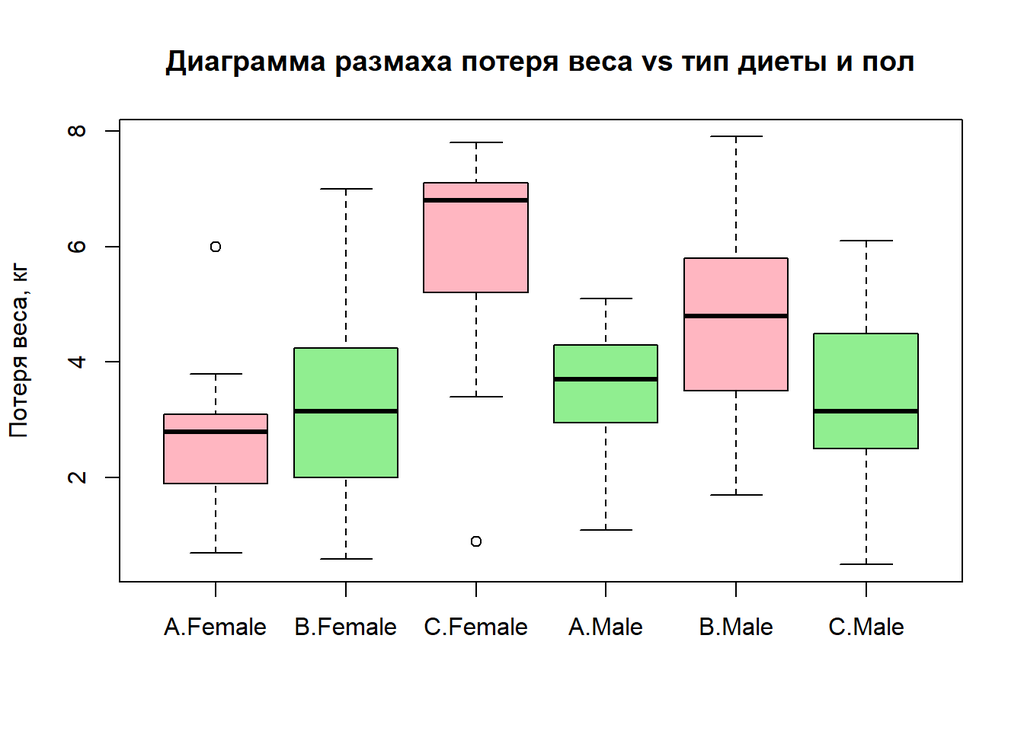

```r
boxplot(weight.loss ~ diet.type * gender, data=data.without.na,col=c("lightpink", "lightgreen"), ylab = "Потеря веса, кг", main="Диаграмма размаха потеря веса vs тип диеты и пол")
```

Из данной диаграммы видно, во-первых что разбивая более детально пол-диета, на диаграмме опять появляются выбросы, которые не были видно до этого. Также можно сделать вывод о том, что лучшая диета для женщин - это диета “С”, а для мужщин - это диета “B”, отсюда же можно увидеть что разброс значений потери веса относительно диеты у женщин больше, чем у мужчин.

2. Построим график групповых средних для двухфакторного дисперсионного анализа:

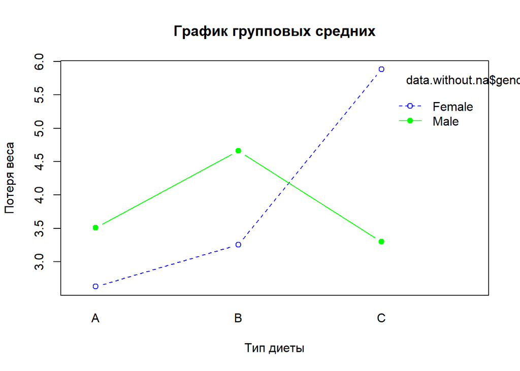

```r
interaction.plot(x.factor = data.without.na$diet.type, trace.factor = data.without.na$gender,
                 response = data.without.na$weight.loss, fun = mean,
                 type = "b", legend = TRUE, xlab = "Тип диеты", ylab="Потеря веса",
                 pch=c(1,19), col = c("blue","green"), main="График групповых средних")
```

Из данного графика четко видно, какая диета в среднем наилучшая, наихудшая, и какая средняя отдельно для женщин и мужчин. Данный график подтверждает предыдущий вывод о диетах.

3. Подгонка ANOVA модели:

```r
data.without.na$type_gender <- interaction(data.without.na$diet.type,data.without.na$gender)
fit.gender.without.outlier2 <- aov(weight.loss ~ type_gender, data=data.without.na)
summary(fit.gender.without.outlier2)
```

```
##             Df Sum Sq Mean Sq F value   Pr(>F)
## type_gender  5  95.03  19.006   6.742 4.47e-05 ***
## Residuals   62 174.77   2.819
## ---
## Signif. codes:  0 '***' 0.001 '**' 0.01 '*' 0.05 '.' 0.1 ' ' 1
```

4. Попарные сравнения:

```r
TukeyHSD(fit.gender.without.outlier2)
```

```
##   Tukey multiple comparisons of means
##     95% family-wise confidence level
##
## Fit: aov(formula = weight.loss ~ type_gender, data = data.without.na)
##
## $type_gender
##                          diff         lwr        upr     p adj
## B.Female-A.Female  0.62756410 -1.34895742  2.6040856 0.9361983
## C.Female-A.Female  3.24923077  1.37830932  5.1201522 0.0000480
## A.Male-A.Female    0.88173077 -1.33690914  3.1003707 0.8498625
## B.Male-A.Female    2.02923077 -0.04752816  4.1059897 0.0591816
## C.Male-A.Female    0.66923077 -1.40752816  2.7459897 0.9322802
## C.Female-B.Female  2.62166667  0.70943955  4.5338938 0.0020510
## A.Male-B.Female    0.25416667 -1.99941461  2.5077479 0.9994417
## B.Male-B.Female    1.40166667 -0.71237996  3.5157133 0.3826560
## C.Male-B.Female    0.04166667 -2.07237996  2.1557133 0.9999999
## A.Male-C.Female   -2.36750000 -4.52905922 -0.2059408 0.0238163
## B.Male-C.Female   -1.22000000 -3.23566437  0.7956644 0.4859612
## C.Male-C.Female   -2.58000000 -4.59566437 -0.5643356 0.0048162
## B.Male-A.Male      1.14750000 -1.19449036  3.4894904 0.7022235
## C.Male-A.Male     -0.21250000 -2.55449036  2.1294904 0.9998074
## C.Male-B.Male     -1.36000000 -3.56804968  0.8480497 0.4662336
```

Из попарного сравнения видно, что *для женщин*:

1. диета “С” самая лучшая
2. диета “В” немного лучше, чем “А”

*для мужчин*:

1. диета “В” самая лучшая
2. диета “А” немного лучше, чем “С”

сравнивая *мужчин* и *женщин*: 1) диета “В” и “А” больше подходят для мужчин

2. соответственно “С” больше подходит для женщин